# EasyVisa Project

## Context:

Business communities in the United States are facing high demand for human resources, but one of the constant challenges is identifying and attracting the right talent, which is perhaps the most important element in remaining competitive. Companies in the United States look for hard-working, talented, and qualified individuals both locally as well as abroad.

The Immigration and Nationality Act (INA) of the US permits foreign workers to come to the United States to work on either a temporary or permanent basis. The act also protects US workers against adverse impacts on their wages or working conditions by ensuring US employers' compliance with statutory requirements when they hire foreign workers to fill workforce shortages. The immigration programs are administered by the Office of Foreign Labor Certification (OFLC).

OFLC processes job certification applications for employers seeking to bring foreign workers into the United States and grants certifications in those cases where employers can demonstrate that there are not sufficient US workers available to perform the work at wages that meet or exceed the wage paid for the occupation in the area of intended employment.

## Objective:

In FY 2016, the OFLC processed 775,979 employer applications for 1,699,957 positions for temporary and permanent labor certifications. This was a nine percent increase in the overall number of processed applications from the previous year. The process of reviewing every case is becoming a tedious task as the number of applicants is increasing every year.

The increasing number of applicants every year calls for a Machine Learning based solution that can help in shortlisting the candidates having higher chances of VISA approval. OFLC has hired your firm EasyVisa for data-driven solutions. You as a data scientist have to analyze the data provided and, with the help of a classification model:

- Facilitate the process of visa approvals.
- Recommend a suitable profile for the applicants for whom the visa should be certified or denied based on the drivers that significantly influence the case status.

## Data Description

The data contains the different attributes of the employee and the employer. The detailed data dictionary is given below.

- case_id: ID of each visa application
- continent: Information of continent the employee
- education_of_employee: Information of education of the employee
- has_job_experience: Does the employee has any job experience? Y= Yes; N = No
- requires_job_training: Does the employee require any job training? Y = Yes; N = No
- no_of_employees: Number of employees in the employer's company
- yr_of_estab: Year in which the employer's company was established
- region_of_employment: Information of foreign worker's intended region of employment in the US.
- prevailing_wage: Average wage paid to similarly employed workers in a specific occupation in the area of intended employment. The purpose of the prevailing wage is to ensure that the foreign worker is not underpaid compared to other workers offering the same or similar service in the same area of employment.
- unit_of_wage: Unit of prevailing wage. Values include Hourly, Weekly, Monthly, and Yearly.
- full_time_position: Is the position of work full-time? Y = Full Time Position; N = Part Time Position
- case_status: Flag indicating if the Visa was certified or denied
- full_time_position: Is the position of work full-time? Y = Full Time Position; N = Part Time Position
- case_status: Flag indicating if the Visa was certified or denied

**Questions**:

1. Those with higher education may want to travel abroad for a well-paid job. Does education play a role in Visa certification?
2. How does the visa status vary across different continents?
3. Experienced professionals might look abroad for opportunities to improve their lifestyles and career development. Does work experience influence visa status?
4. In the United States, employees are paid at different intervals. Which pay unit is most likely to be certified for a visa?
5. The US government has established a prevailing wage to protect local talent and foreign workers. How does the visa status change with the prevailing wage?

```python
import pandas as pd
import numpy as np
from sklearn import metrics
import matplotlib.pyplot as plt
%matplotlib inline
import warnings
warnings.filterwarnings('ignore')
import seaborn as sns
from sklearn.model_selection import train_test_split
from sklearn.model_selection import GridSearchCV
from sklearn import metrics
from sklearn.ensemble import BaggingClassifier, RandomForestClassifier
from sklearn.linear_model import LogisticRegression
from sklearn.model_selection import RandomizedSearchCV
from sklearn.inspection import permutation_importance
# Libraries to import decision tree classifier and different ensemble classifiers
from sklearn.tree import DecisionTreeClassifier
from sklearn import tree
#from xgboost import XGBClassifier
from xgboost import XGBClassifier
from sklearn.ensemble import AdaBoostClassifier, GradientBoostingClassifier
import scipy.stats as stat
from sklearn.ensemble import StackingClassifier

# Libtune to tune model, get different metric scores
from sklearn import metrics
from sklearn.metrics import confusion_matrix, classification_report, accuracy_score, precision_score, recall_score,f1_score,roc_auc_score
```

```python
data = pd.read_csv('F:\Projets_Python\Datasets\EasyVisa.csv') # importing the data
df = data.copy() #making a copy of the data in case of bad manipulation
np.random.seed(1)
df.sample(10)#showing a random sample of the dataset
```

|  | case_id | continent | education_of_employee | has_job_experience | requires_job_training | no_of_employees | yr_of_estab | region_of_employment | prevailing_wage | unit_of_wage | full_time_position | case_status |
| --- | --- | --- | --- | --- | --- | --- | --- | --- | --- | --- | --- | --- |
| 17639 | EZYV17640 | Asia | Bachelor's | Y | N | 567 | 1992 | Midwest | 26842.9100 | Year | Y | Certified |
| 23951 | EZYV23952 | Oceania | Bachelor's | N | N | 619 | 1938 | Midwest | 66419.9800 | Year | Y | Certified |
| 8625 | EZYV8626 | Asia | Master's | N | N | 2635 | 2005 | South | 887.2921 | Hour | Y | Certified |
| 20206 | EZYV20207 | Asia | Bachelor's | Y | Y | 3184 | 1986 | Northeast | 49435.8000 | Year | Y | Certified |
| 7471 | EZYV7472 | Europe | Bachelor's | Y | N | 4681 | 1928 | West | 49865.1900 | Year | Y | Denied |
| 3433 | EZYV3434 | Asia | Bachelor's | Y | N | 222 | 1989 | South | 813.7261 | Hour | Y | Certified |
| 24440 | EZYV24441 | Europe | High School | N | Y | 3278 | 1994 | South | 204948.3900 | Year | Y | Denied |
| 12104 | EZYV12105 | Asia | Master's | Y | N | 1359 | 1997 | West | 202237.0400 | Year | N | Certified |
| 15656 | EZYV15657 | Asia | Bachelor's | N | N | 2081 | 2003 | West | 111713.0200 | Year | Y | Denied |
| 23110 | EZYV23111 | North America | Bachelor's | Y | N | 854 | 1998 | Northeast | 444.8257 | Hour | Y | Denied |

```python
df.shape #dataset size
```

```
(25480, 12)
```

```python
df.info() #type of variables
```

```
<class 'pandas.core.frame.DataFrame'>
RangeIndex: 25480 entries, 0 to 25479
Data columns (total 12 columns):
 #   Column                 Non-Null Count  Dtype
---  ------                 --------------  -----
 0   case_id                25480 non-null  object
 1   continent              25480 non-null  object
 2   education_of_employee  25480 non-null  object
 3   has_job_experience     25480 non-null  object
 4   requires_job_training  25480 non-null  object
 5   no_of_employees        25480 non-null  int64
 6   yr_of_estab            25480 non-null  int64
 7   region_of_employment   25480 non-null  object
 8   prevailing_wage        25480 non-null  float64
 9   unit_of_wage           25480 non-null  object
 10  full_time_position     25480 non-null  object
 11  case_status            25480 non-null  object
dtypes: float64(1), int64(2), object(9)
memory usage: 2.3+ MB
```

```python
df.isnull().sum() #checking null values
```

```
case_id                  0
continent                0
education_of_employee    0
has_job_experience       0
requires_job_training    0
no_of_employees          0
yr_of_estab              0
region_of_employment     0
prevailing_wage          0
unit_of_wage             0
full_time_position       0
case_status              0
dtype: int64
```

```python
num_to_display = 10  # defining this up here so it's easy to change later if I want
for colname in df.dtypes[df.dtypes == 'object'].index:#loop over objects columns
    val_counts = df[colname].value_counts(dropna=False)  # i want to see NA counts
    print(val_counts[:num_to_display])
    if len(val_counts) > num_to_display:
        print(f'Only displaying first {num_to_display} of {len(val_counts)} values.')
    print('\n\n') # just for more space between
```

```
EZYV6568     1
EZYV15235    1
EZYV16261    1
EZYV17481    1
EZYV19161    1
EZYV6517     1
EZYV639      1
EZYV18917    1
EZYV19053    1
EZYV23116    1
Name: case_id, dtype: int64
Only displaying first 10 of 25480 values.



Asia             16861
Europe            3732
North America     3292
South America      852
Africa             551
Oceania            192
Name: continent, dtype: int64



Bachelor's     10234
Master's        9634
High School     3420
Doctorate       2192
Name: education_of_employee, dtype: int64



Y    14802
N    10678
Name: has_job_experience, dtype: int64



N    22525
```

[output cut: 16 more lines]

```
Week       272
Month       89
Name: unit_of_wage, dtype: int64



Y    22773
N     2707
Name: full_time_position, dtype: int64



Certified    17018
Denied        8462
Name: case_status, dtype: int64
```

```python
df = df.drop('case_id', axis=1) # droping the case_id column
df.head()#checking
```

|  | continent | education_of_employee | has_job_experience | requires_job_training | no_of_employees | yr_of_estab | region_of_employment | prevailing_wage | unit_of_wage | full_time_position | case_status |
| --- | --- | --- | --- | --- | --- | --- | --- | --- | --- | --- | --- |
| 0 | Asia | High School | N | N | 14513 | 2007 | West | 592.2029 | Hour | Y | Denied |
| 1 | Asia | Master's | Y | N | 2412 | 2002 | Northeast | 83425.6500 | Year | Y | Certified |
| 2 | Asia | Bachelor's | N | Y | 44444 | 2008 | West | 122996.8600 | Year | Y | Denied |
| 3 | Asia | Bachelor's | N | N | 98 | 1897 | West | 83434.0300 | Year | Y | Denied |
| 4 | Africa | Master's | Y | N | 1082 | 2005 | South | 149907.3900 | Year | Y | Certified |

```python
df[df['no_of_employees']<0].count() #checking negative values
```

```
continent                33
education_of_employee    33
has_job_experience       33
requires_job_training    33
no_of_employees          33
yr_of_estab              33
region_of_employment     33
prevailing_wage          33
unit_of_wage             33
full_time_position       33
case_status              33
dtype: int64
```

```python
df.drop(df[df.no_of_employees < 0].index, inplace=True) #eliminating negative values
```

```python
df[df['no_of_employees']<0].count() #checking
```

```
continent                0
education_of_employee    0
has_job_experience       0
requires_job_training    0
no_of_employees          0
yr_of_estab              0
region_of_employment     0
prevailing_wage          0
unit_of_wage             0
full_time_position       0
case_status              0
dtype: int64
```

In 1965, the US governement drastically change its immigration policy from a quota system to a classic system (no quota). The quota system favour european immigration versu others. In addition, there was some key events in immigration that affects the data before 1965 like the Chinese Immigration Act voted in 1882 which ban chinese from US soil. This law was enforced until 1902, where it was renewed until 1943. The Ferguson law, voted in 1943 put an end to this law. (Source : https://en.wikipedia.org/wiki/Chinese_Exclusion_Act) This law doesn't affect only chinese people but people with "chinese" etchnicity. So, by an large, this law ban immigration from asian countries. There was a period with almost no immigration in the US between 1930's and 1950's (Source : https://www.history.com/topics/immigration/u-s-immigration-before-1965). This wasn't only the consequence of WWII. During this period people from immigration fall from 11,6% to 6,9% of the total population. After WWII there was also the Bracero program which was an employment program for people from Mexico, 4,6 million mexican people benefit from this program. After 1965 there were also several phases. In 1986, President Reagan regularized 3 million illegal migrants. In 2001, the DREAM act voted, paving the way for minor migrants to get citizenship.

Dataset Consequence :

- 1800-1882 : european wave
- 1882 - 1943 : the Chinese immigration Act
- 1943 - 1965 : the Bracero Program and the end of the Chinese Immigration Act
- 1965 - 1986 : end of quota to regularization of illegal immigration
- 1986 - 2001 : from regularization of illegal immigration to Dream Act
- 2001 - 2016 : DREAM act

### **Dataset split**

```python
bins = (np.min(df['yr_of_estab']), 1882, 1943, 1965, 1986, 2001, np.max(df['yr_of_estab'])) # determining the key years to bin
label = ['1800_1882', '1882_1943', '1943_1965','1965_1986','1986_2001','2001_2016'] #labeling the period

df['yr_split']= pd.cut(df['yr_of_estab'], bins=bins, labels=label) #cutting the yr_of_estab
```

```python
df_year_bin = df.drop('yr_of_estab', axis=1) #eliminating the yr_of_estab
```

```python
np.random.seed(1)
df_year_bin.sample(10) #checking on a dataset random sample
```

|  | continent | education_of_employee | has_job_experience | requires_job_training | no_of_employees | region_of_employment | prevailing_wage | unit_of_wage | full_time_position | case_status | yr_split |
| --- | --- | --- | --- | --- | --- | --- | --- | --- | --- | --- | --- |
| 6675 | Asia | Bachelor's | Y | N | 1198 | South | 92156.82 | Year | Y | Certified | 1965_1986 |
| 1254 | Asia | High School | Y | N | 364 | Northeast | 55294.64 | Year | Y | Denied | 1986_2001 |
| 22567 | Europe | Doctorate | Y | N | 4596 | South | 58706.21 | Year | Y | Certified | 1943_1965 |
| 21354 | Europe | Bachelor's | N | Y | 2361 | West | 129520.23 | Year | Y | Denied | 1943_1965 |
| 7233 | Asia | Bachelor's | Y | N | 1729 | Midwest | 132996.89 | Year | Y | Certified | 2001_2016 |
| 15128 | Asia | Bachelor's | N | N | 2305 | Northeast | 22317.89 | Year | Y | Certified | 2001_2016 |
| 24159 | North America | Bachelor's | Y | N | 1058 | West | 65068.10 | Year | Y | Certified | 1986_2001 |
| 22269 | Asia | Master's | N | N | 1969 | Northeast | 166818.97 | Year | N | Certified | 1986_2001 |
| 13483 | Asia | Master's | N | N | 3475 | West | 46571.67 | Year | Y | Denied | 1882_1943 |
| 5694 | Asia | Bachelor's | Y | N | 771 | Northeast | 42672.94 | Year | Y | Certified | 2001_2016 |

Now we have the two dataset, we will explore each of them to understand how the data works.

## **Dataset EDA**

### **Univariate Analysis**

```python
list_col_num = df_year_bin.select_dtypes(include=np.number).columns.to_list() #put number column into a list
```

```python
def histogram_boxplot(data, feature, kde=True, figsize=(12, 7), bins=None):
    """
    Boxplot and histogram combined
    data: dataframe
    feature: dataframe column
    figsize: size of figure (default (12,7))
    kde: whether to show the density curve (default False)
    bins: number of bins for histogram (default None)
    """
    f2, (ax_box2, ax_hist2) = plt.subplots(
        nrows=2,  # Number of rows of the subplot grid= 2
        sharex=True,  # x-axis will be shared among all subplots
        gridspec_kw={"height_ratios": (0.25, 0.75)},
        figsize=figsize,
    )  # creating the 2 subplots
    mode = data[feature].mode()

    sns.boxplot(
        data=data, x=feature, ax=ax_box2, showmeans=True, color="violet"
    )  # boxplot will be created and a star will indicate the mean value of the column
    sns.histplot(
        data=data, x=feature, kde=kde, ax=ax_hist2, bins=bins, palette="winter"
    ) if bins else sns.histplot(
        data=data, x=feature, kde=kde, ax=ax_hist2
    )  # For histogram
    ax_hist2.axvline(
        data[feature].mean(), color="green", linestyle="--"
    )  # Add mean to the histogram
    ax_hist2.axvline(
        data[feature].median(), color="black", linestyle="-"
    )  # Add median to the histogram
    ax_hist2.axvline(mode[0], color="red", linestyle='-')
        #Add mode to the histogram
```

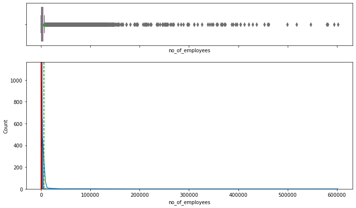

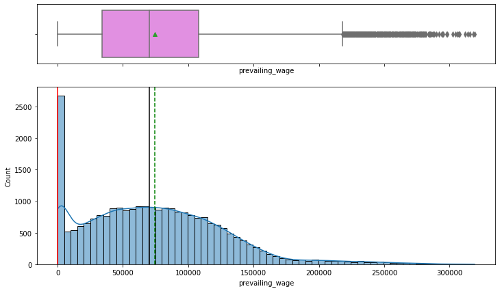

```python
for col in list_col_num: #loop over the numeric column of the dataset
    histogram_boxplot(df, col, kde=True)
```

**Observations**

```python
df_year_bin.describe(include=np.number).T
```

|  | count | mean | std | min | 25% | 50% | 75% | max |
| --- | --- | --- | --- | --- | --- | --- | --- | --- |
| no_of_employees | 25447.0 | 5674.415334 | 22891.842245 | 12.0000 | 1025.00 | 2112.0 | 3506.500 | 602069.00 |
| prevailing_wage | 25447.0 | 74468.281479 | 52822.177370 | 2.1367 | 34039.21 | 70312.5 | 107739.505 | 319210.27 |

**Observations**

```python
# function to create labeled barplots

def labeled_barplot(data, feature, perc=False, n=None):
    """
    Barplot with percentage at the top

    data: dataframe
    feature: dataframe column
    perc: whether to display percentages instead of count (default is False)
    n: displays the top n category levels (default is None, i.e., display all levels)
    """

    total = len(data[feature])  # length of the column
    count = data[feature].nunique()#count unique values
    #this condition below adapt the figsize depending on the unique values
    if n is None:
        plt.figure(figsize=(count + 1, 5))
    else:
        plt.figure(figsize=(n + 1, 5))

    plt.xticks(rotation=90, fontsize=15)
    ax = sns.countplot(
        data=data,
        x=feature,
        palette="Paired",
        order=data[feature].value_counts().index[:n].sort_values(),
    )

    for p in ax.patches:
        if perc == True:
            label = "{:.1f}%".format(
                100 * p.get_height() / total
            )  # percentage of each class of the category
        else:
            label = p.get_height()  # count of each level of the category

        x = p.get_x() + p.get_width() / 2  # width of the plot
        y = p.get_height()  # height of the plot

        ax.annotate(
            label,
            (x, y),
            ha="center",
            va="center",
            size=12,
            xytext=(0, 5),
            textcoords="offset points",
        )  # annotate the percentage

    plt.show()  # show the plot
```

```python
list_col_obj = df_year_bin.select_dtypes(include='object').columns.to_list() #putting in a list the object column
```

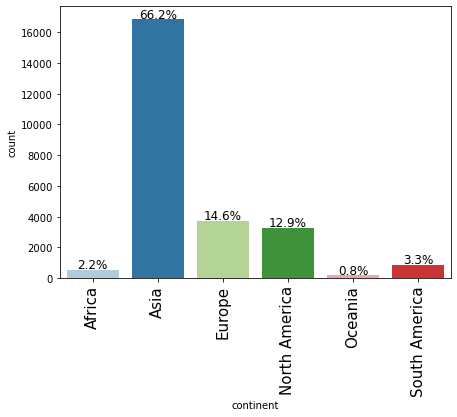

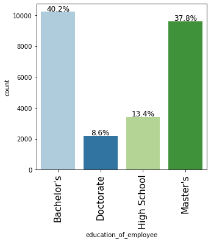

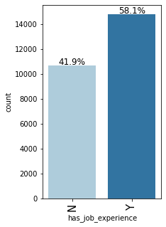

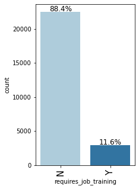

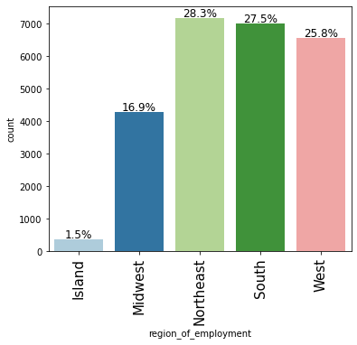

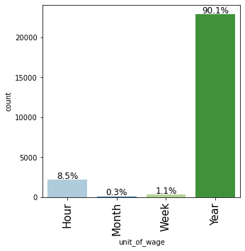

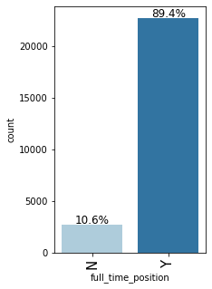

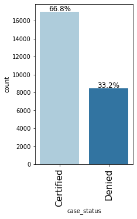

```python
for col in list_col_obj: #looping over the object column list in order to execute the labeled barplot function
    labeled_barplot(df_year_bin, col, perc=True)
```

**Observations**

- continent : Asia is dominating immigration origin in the US (66% of total). Than came Europe with a low 14,6% and North America (Canada/Quebec) with 12.9%
- education : Most of migrants candidate have a Bachelor's (40.2%) or a Master's degree (37.8%), few migrants have a High School grade (13.4%)
- job experience : migrants candidate with job experience represents a majority (58%)
- job training : most of migrants candidates does not need job training (88%) which is coherent with the level of education (>80% have a Bachelor or a Master degree)
- region of employment : Northeast, South and West are catching the biggest share of the migrants candidate (81,6%)
- unit of wage : a vast majority of the migrant candidates are paid on a yearly basis (90%)
- full time position : a vast majority of the migrants candidates have a full time position (89%)
- case status : 66.8% of the migrant candidate are certified leaving 33% of the migrant candidate with a denied decision.

### **Bivariate Analysis**

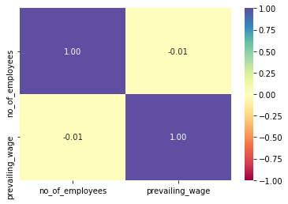

```python
cor = df_year_bin.corr()
sns.heatmap(cor, annot=True, vmin=-1, vmax=1, fmt=".2f", cmap="Spectral")
```

**Observations**

- No correlation to take care of

```python
def stacked_barplot(data, predictor, target):
    """
    Print the category counts and plot a stacked bar chart

    data: dataframe
    predictor: independent variable
    target: target variable
    """
    count = data[predictor].nunique()
    sorter = data[target].value_counts().index[-1]
    tab1 = pd.crosstab(data[predictor], data[target], margins=True).sort_values(
        by=sorter, ascending=False
    )
    print(tab1)
    print("-" * 120)
    tab = pd.crosstab(data[predictor], data[target], normalize="index").sort_values(
        by=sorter, ascending=False
    )
    tab.plot(kind="bar", stacked=True, figsize=(count + 5, 5))
    plt.legend(
        loc="lower left", frameon=False,
    )
    plt.legend(loc="upper left", bbox_to_anchor=(1, 1))
    plt.show()
```

```
case_status    Certified  Denied    All
continent
All                17001    8446  25447
Asia               11001    5839  16840
North America       2037    1250   3287
Europe              2953     774   3727
South America        492     359    851
Africa               396     154    550
Oceania              122      70    192
------------------------------------------------------------------------------------------------------------------------
```

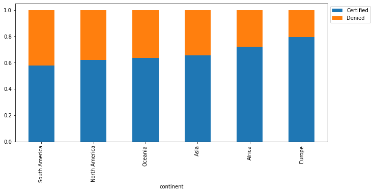

```
case_status            Certified  Denied    All
education_of_employee
All                        17001    8446  25447
Bachelor's                  6362    3858  10220
High School                 1164    2252   3416
Master's                    7565    2057   9622
Doctorate                   1910     279   2189
------------------------------------------------------------------------------------------------------------------------
```

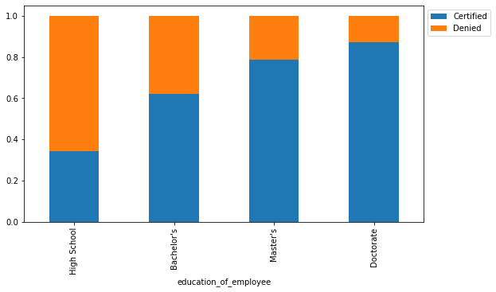

```
case_status         Certified  Denied    All
has_job_experience
All                     17001    8446  25447
N                        5986    4675  10661
Y                       11015    3771  14786
------------------------------------------------------------------------------------------------------------------------
```

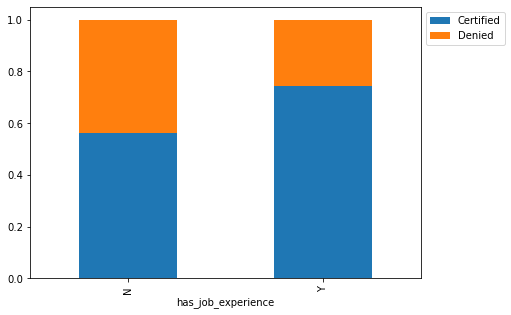

```
case_status            Certified  Denied    All
requires_job_training
All                        17001    8446  25447
N                          15000    7498  22498
Y                           2001     948   2949
------------------------------------------------------------------------------------------------------------------------
```

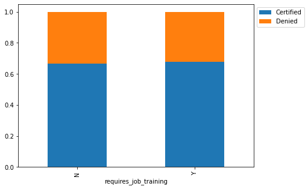

```
case_status           Certified  Denied    All
region_of_employment
All                       17001    8446  25447
Northeast                  4524    2665   7189
West                       4097    2481   6578
South                      4908    2098   7006
Midwest                    3246    1053   4299
Island                      226     149    375
------------------------------------------------------------------------------------------------------------------------
```

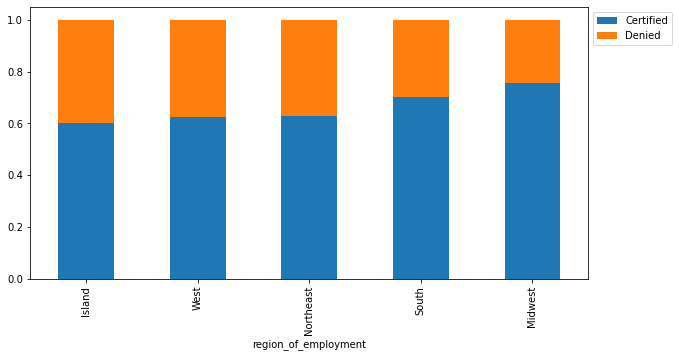

```
case_status   Certified  Denied    All
unit_of_wage
All               17001    8446  25447
Year              16030    6903  22933
Hour                747    1406   2153
Week                169     103    272
Month                55      34     89
------------------------------------------------------------------------------------------------------------------------
```

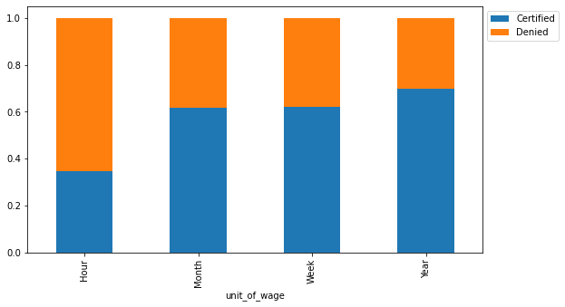

```
case_status         Certified  Denied    All
full_time_position
All                     17001    8446  25447
Y                       15146    7595  22741
N                        1855     851   2706
------------------------------------------------------------------------------------------------------------------------
```

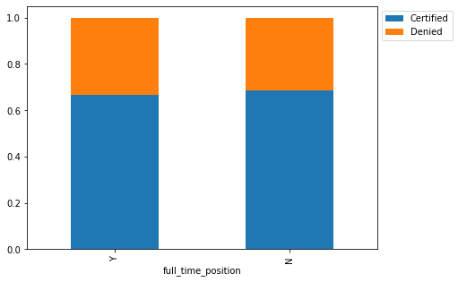

```
case_status  Certified  Denied    All
case_status
Denied               0    8446   8446
All              17001    8446  25447
Certified        17001       0  17001
------------------------------------------------------------------------------------------------------------------------
```

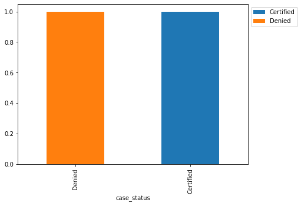

```python
for col in list_col_obj:
    stacked_barplot(df_year_bin, col, "case_status")
```

**Observations**

```python
### function to plot distributions wrt target


def distribution_plot_wrt_target(data, predictor, target):

    fig, axs = plt.subplots(2, 2, figsize=(12, 10))

    target_uniq = data[target].unique()

    axs[0, 0].set_title("Distribution of target for target=" + str(target_uniq[0]))
    sns.histplot(
        data=data[data[target] == target_uniq[0]],
        x=predictor,
        kde=True,
        ax=axs[0, 0],
        color="teal",
        stat="density",
    )

    axs[0, 1].set_title("Distribution of target for target=" + str(target_uniq[1]))
    sns.histplot(
        data=data[data[target] == target_uniq[1]],
        x=predictor,
        kde=True,
        ax=axs[0, 1],
        color="orange",
        stat="density",
    )

    axs[1, 0].set_title("Boxplot w.r.t target")
    sns.boxplot(data=data, x=target, y=predictor, ax=axs[1, 0], palette="gist_rainbow")

    axs[1, 1].set_title("Boxplot (without outliers) w.r.t target")
    sns.boxplot(
        data=data,
        x=target,
        y=predictor,
        ax=axs[1, 1],
        showfliers=False,
        palette="gist_rainbow",
    )

    plt.tight_layout()
    plt.show()
```

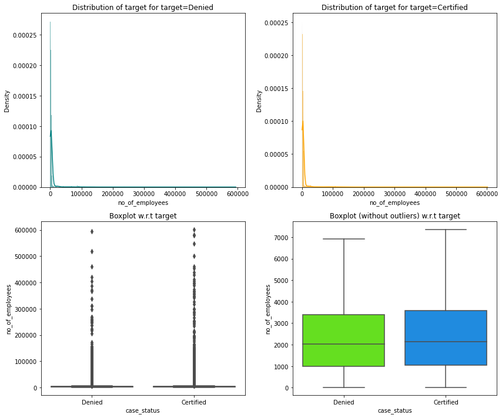

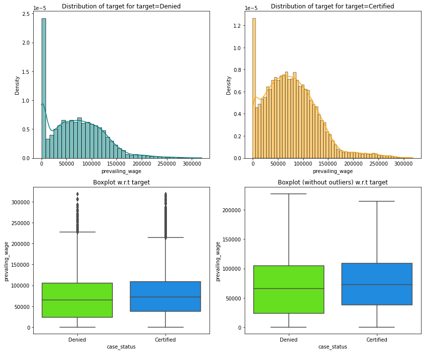

```python
for col in list_col_num:
    distribution_plot_wrt_target(df_year_bin, col, 'case_status')
```

**Observations**

- no of employee : not sure it's relevant here
- prevailing wage : difference looks thin between denied and certified which may be explained by the fact that there is a minimum prerequisite before asking for a visa.

### **EDA for each time period**

```python
df_year_bin['case_status']=df_year_bin['case_status'].replace(to_replace='Denied', value=0) # changing case status str to int value
```

```python
df_year_bin['case_status']=df_year_bin['case_status'].replace(to_replace='Certified', value=1) # changing case status str to int value
```

```python
df_year_bin_denied = df_year_bin.query('case_status==0')
```

```python
df_year_bin_denied.shape
```

```
(8446, 11)
```

```python
df_year_bin_certified = df_year_bin.query('case_status==1')
```

```python
df_year_bin_certified.shape
```

```
(17001, 11)
```

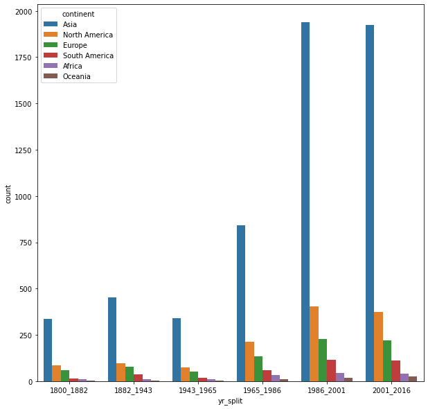

```python
plt.figure(figsize=[10,10])
sns.countplot(data=df_year_bin_denied, x='yr_split', hue='continent')
```

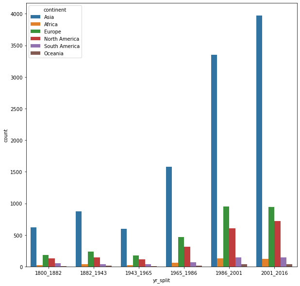

```python
plt.figure(figsize=[10,10])
sns.countplot(data=df_year_bin_certified, x='yr_split', hue='continent')
```

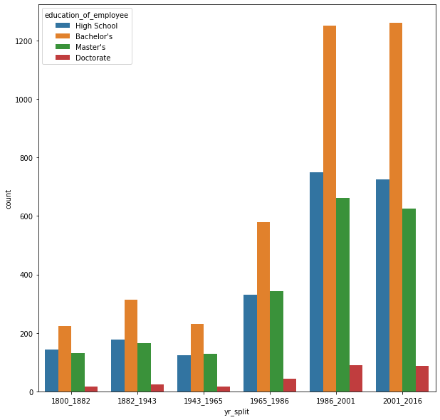

```python
plt.figure(figsize=[10,10])
sns.countplot(data=df_year_bin_denied, x='yr_split', hue='education_of_employee')
```

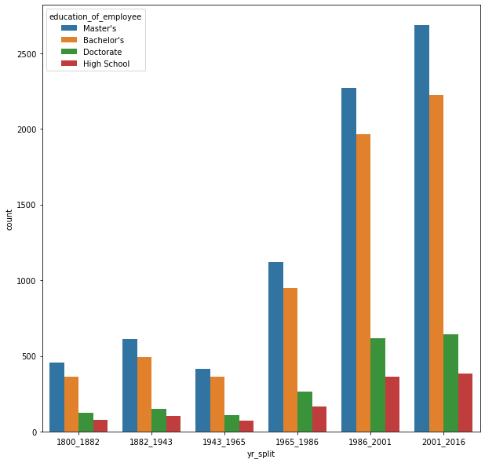

```python
plt.figure(figsize=[10,10])
sns.countplot(data=df_year_bin_certified, x='yr_split', hue='education_of_employee')
```

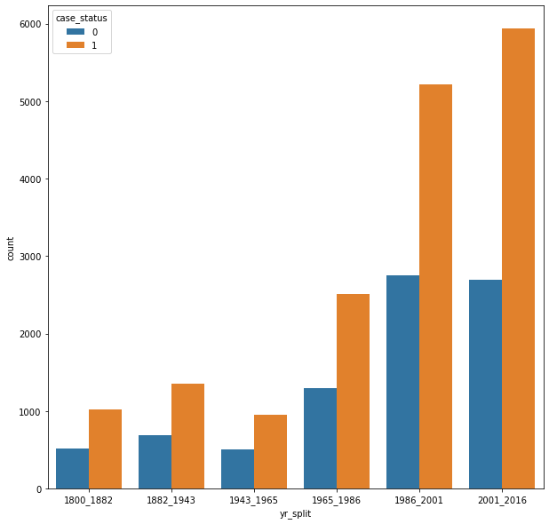

```python
plt.figure(figsize=[10,10])
sns.countplot(data=df_year_bin, x='yr_split', hue='case_status')
```

```python
df_year_bin.groupby(['yr_split','case_status']).count()
```

| yr_split | case_status | continent | education_of_employee | has_job_experience | requires_job_training | no_of_employees | region_of_employment | prevailing_wage | unit_of_wage | full_time_position |
| --- | --- | --- | --- | --- | --- | --- | --- | --- | --- | --- |
| 1800_1882 | 0 | 513 | 513 | 513 | 513 | 513 | 513 | 513 | 513 | 513 |
|  | 1 | 1021 | 1021 | 1021 | 1021 | 1021 | 1021 | 1021 | 1021 | 1021 |
| 1882_1943 | 0 | 682 | 682 | 682 | 682 | 682 | 682 | 682 | 682 | 682 |
|  | 1 | 1357 | 1357 | 1357 | 1357 | 1357 | 1357 | 1357 | 1357 | 1357 |
| 1943_1965 | 0 | 499 | 499 | 499 | 499 | 499 | 499 | 499 | 499 | 499 |
|  | 1 | 957 | 957 | 957 | 957 | 957 | 957 | 957 | 957 | 957 |
| 1965_1986 | 0 | 1295 | 1295 | 1295 | 1295 | 1295 | 1295 | 1295 | 1295 | 1295 |
|  | 1 | 2505 | 2505 | 2505 | 2505 | 2505 | 2505 | 2505 | 2505 | 2505 |
| 1986_2001 | 0 | 2753 | 2753 | 2753 | 2753 | 2753 | 2753 | 2753 | 2753 | 2753 |
|  | 1 | 5215 | 5215 | 5215 | 5215 | 5215 | 5215 | 5215 | 5215 | 5215 |
| 2001_2016 | 0 | 2699 | 2699 | 2699 | 2699 | 2699 | 2699 | 2699 | 2699 | 2699 |
|  | 1 | 5935 | 5935 | 5935 | 5935 | 5935 | 5935 | 5935 | 5935 | 5935 |

**Observations**

Here we would like to assess the differences through time regarding the different period.

- there is a before and an after 1965. The immigration numbers grew strongly after the immigration act of 1965 which make sens because this legal text abolish the quota system, which prevail before.
- Having said that, we can confirm the same trend over time. The continent origin split is the same during all the period, the education split is the same.
- The certified ratio is constant through time (66-68%)

### **Statistical check on supposed relation between case status and education, interval of payment and prevailing wage**

```python
for col in  list_col_obj: # changing object type column to category type columns
    df_year_bin[col]=df_year_bin[col].astype('category')
```

```python
df_year_bin.info()#checking
```

```
<class 'pandas.core.frame.DataFrame'>
Int64Index: 25447 entries, 0 to 25479
Data columns (total 11 columns):
 #   Column                 Non-Null Count  Dtype
---  ------                 --------------  -----
 0   continent              25447 non-null  category
 1   education_of_employee  25447 non-null  category
 2   has_job_experience     25447 non-null  category
 3   requires_job_training  25447 non-null  category
 4   no_of_employees        25447 non-null  int64
 5   region_of_employment   25447 non-null  category
 6   prevailing_wage        25447 non-null  float64
 7   unit_of_wage           25447 non-null  category
 8   full_time_position     25447 non-null  category
 9   case_status            25447 non-null  category
 10  yr_split               25431 non-null  category
dtypes: category(9), float64(1), int64(1)
memory usage: 2.1 MB
```

```python
df_year_bin.head()#checking
```

|  | continent | education_of_employee | has_job_experience | requires_job_training | no_of_employees | region_of_employment | prevailing_wage | unit_of_wage | full_time_position | case_status | yr_split |
| --- | --- | --- | --- | --- | --- | --- | --- | --- | --- | --- | --- |
| 0 | Asia | High School | N | N | 14513 | West | 592.2029 | Hour | Y | 0 | 2001_2016 |
| 1 | Asia | Master's | Y | N | 2412 | Northeast | 83425.6500 | Year | Y | 1 | 2001_2016 |
| 2 | Asia | Bachelor's | N | Y | 44444 | West | 122996.8600 | Year | Y | 0 | 2001_2016 |
| 3 | Asia | Bachelor's | N | N | 98 | West | 83434.0300 | Year | Y | 0 | 1882_1943 |
| 4 | Africa | Master's | Y | N | 1082 | South | 149907.3900 | Year | Y | 1 | 2001_2016 |

```python
df_year_bin['continent']=df_year_bin['continent'].replace(to_replace='North America', value='North_America') # switching space with "_"
```

```python
df_year_bin['continent']=df_year_bin['continent'].replace(to_replace='South America', value='South_America') # switching space with "_"
```

```python
df_year_bin['education_of_employee']=df_year_bin['education_of_employee'].replace(to_replace='High School', value='high_School')#switching space with "_"
```

```python
df_year_bin['education_of_employee']=df_year_bin['education_of_employee'].replace(to_replace='Master\'s', value='Masters')#switching space with "_"
```

```python
df_year_bin['education_of_employee']=df_year_bin['education_of_employee'].replace(to_replace='Bachelor\'s', value='Bachelors')#switching space with "_"
```

```python
list_dum = df_year_bin['continent']
df_stat = pd.get_dummies(df_year_bin, columns=['continent']) # dummies the continent variable for statistic treatment
```

```python
df_stat.head() #checking
```

|  | education_of_employee | has_job_experience | requires_job_training | no_of_employees | region_of_employment | prevailing_wage | unit_of_wage | full_time_position | case_status | yr_split | continent_Africa | continent_Asia | continent_Europe | continent_North_America | continent_Oceania | continent_South_America |
| --- | --- | --- | --- | --- | --- | --- | --- | --- | --- | --- | --- | --- | --- | --- | --- | --- |
| 0 | high_School | N | N | 14513 | West | 592.2029 | Hour | Y | 0 | 2001_2016 | 0 | 1 | 0 | 0 | 0 | 0 |
| 1 | Masters | Y | N | 2412 | Northeast | 83425.6500 | Year | Y | 1 | 2001_2016 | 0 | 1 | 0 | 0 | 0 | 0 |
| 2 | Bachelors | N | Y | 44444 | West | 122996.8600 | Year | Y | 0 | 2001_2016 | 0 | 1 | 0 | 0 | 0 | 0 |
| 3 | Bachelors | N | N | 98 | West | 83434.0300 | Year | Y | 0 | 1882_1943 | 0 | 1 | 0 | 0 | 0 | 0 |
| 4 | Masters | Y | N | 1082 | South | 149907.3900 | Year | Y | 1 | 2001_2016 | 1 | 0 | 0 | 0 | 0 | 0 |

## Hypothesis Formulation

```
Ho : p1=p2, there is no difference between the two proportion

Ha : p1 != p2, there is a difference between the two proporitions
```

#### Z-test assumptions checking

Binomally distributed population - Yes, a person can be either certified or not certified.

Random sampling from the population - Yes, we are informed that the collected sample is a simple random sample.

Can the binomial distribution approximated to normal distribution - Yes. For binary data, CLT works slower than usual. The standard thing is to check whether np and n(1-p) are greater than or equal to 10. Here, n and p refer to the sample size and sample proportion respectively.

All the proportion we are looking for are above the 10% level, so all the assumptions are validated.

### **Is there a difference in case status depending on education ?**

```python
df_stat3 = pd.get_dummies(df_year_bin, columns=['education_of_employee'])# dummies the education of employee variable
```

```python
df_stat3.head()
```

|  | continent | has_job_experience | requires_job_training | no_of_employees | region_of_employment | prevailing_wage | unit_of_wage | full_time_position | case_status | yr_split | education_of_employee_Bachelors | education_of_employee_Doctorate | education_of_employee_high_School | education_of_employee_Masters |
| --- | --- | --- | --- | --- | --- | --- | --- | --- | --- | --- | --- | --- | --- | --- |
| 0 | Asia | N | N | 14513 | West | 592.2029 | Hour | Y | 0 | 2001_2016 | 0 | 0 | 1 | 0 |
| 1 | Asia | Y | N | 2412 | Northeast | 83425.6500 | Year | Y | 1 | 2001_2016 | 0 | 0 | 0 | 1 |
| 2 | Asia | N | Y | 44444 | West | 122996.8600 | Year | Y | 0 | 2001_2016 | 1 | 0 | 0 | 0 |
| 3 | Asia | N | N | 98 | West | 83434.0300 | Year | Y | 0 | 1882_1943 | 1 | 0 | 0 | 0 |
| 4 | Africa | Y | N | 1082 | South | 149907.3900 | Year | Y | 1 | 2001_2016 | 0 | 0 | 0 | 1 |

```python
#import the appropriate function
from statsmodels.stats.proportion import proportions_ztest

# Bachelor's Denied Count
df_stat_prop_bach = df_stat3.query('education_of_employee_Bachelors==1')
df_stat_prop_bach2=df_stat_prop_bach.query('case_status==0')
m = df_stat_prop_bach2.shape[0]

#Doctorate Denied count
df_stat_prop_PhD = df_stat3.query('education_of_employee_Doctorate==1')
df_stat_prop_PhD2 = df_stat_prop_PhD.query('case_status==0')
n = df_stat_prop_PhD2.shape[0]

#High School Denied count
df_stat_prop_HS = df_stat3.query('education_of_employee_high_School==1')
df_stat_prop_HS2 = df_stat_prop_HS.query('case_status==0')
o = df_stat_prop_HS2.shape[0]

#Master's Denied count
df_stat_prop_MS = df_stat3.query('education_of_employee_Masters == 1')
df_stat_prop_MS2 = df_stat_prop_MS.query('case_status == 0')
p = df_stat_prop_MS2.shape[0]

education_dict = { 'Bachelors':[df_year_bin.loc[df_year_bin['education_of_employee']=='Bachelors','education_of_employee'].count(),m],
               'Doctorate':[df_year_bin.loc[df_year_bin['education_of_employee']=='Doctorate','education_of_employee'].count(), n],
                'High_School':[df_year_bin.loc[df_year_bin['education_of_employee']=='High_School','education_of_employee'].count(),o],
                'Masters':[df_year_bin.loc[df_year_bin['education_of_employee']=='Masters','education_of_employee'].count(),p]
                }


#build a list with all the denied value per continent for further usage
list_value_edu = [m,n,o,p]
#build an empty dictionnary
dict_value_edu = {'Bachelors':[],
              'Doctorate':[],
              'High_School':[],
              'Masters':[],
              }

#building an index for result dataframe
list_index = pd.Series(['Bachelors','Doctorate','High_School','Masters'])

#building an empty dataframe for further usage
df_prop_edu = pd.DataFrame()

#calculating Denied proportion p_value between continents
for key_ref, value_refs in education_dict.items():
    for value_ref in value_refs:
        if value_ref in list_value_edu:
            for key, values in education_dict.items():
                for value in values:
                    if value in list_value_edu:
                        converted_count = np.array([value_ref,value])
                    #build an array with the total count of each group
                    else :
                        nobs = np.array([value_ref,value])
                test_var, p_value = proportions_ztest(converted_count, nobs)
                dict_value_edu[key_ref].append(p_value)
df_prop_pval = pd.DataFrame.from_dict(dict_value_edu, orient='columns')
df_prop_pval2=df_prop_pval.set_index(list_index)
df_prop_pval2.head(10)
```

|  | Bachelors | Doctorate | High_School | Masters |
| --- | --- | --- | --- | --- |
| Bachelors | 0.0 | 7.369671e-98 | 0.0 | 0.0 |
| Doctorate | 0.0 | 3.790678e-236 | 0.0 | 0.0 |
| High_School | NaN | NaN | NaN | NaN |
| Masters | 0.0 | 3.390884e-204 | 0.0 | 0.0 |

### **Is there a difference depending on continent origin ?**

```python
#import the appropriate function
from statsmodels.stats.proportion import proportions_ztest

# Europe Denied Count
df_stat_prop_eur = df_stat.query('continent_Europe==1')
df_stat_prop_eur2=df_stat_prop_eur.query('case_status==0')
a = df_stat_prop_eur2.shape[0]

#Asian Denied count
df_stat_prop_asia = df_stat.query('continent_Asia==1')
df_stat_prop_asia2 = df_stat_prop_asia.query('case_status==0')
b = df_stat_prop_asia2.shape[0]

#African Denied count
df_stat_prop_africa = df_stat.query('continent_Africa==1')
df_stat_prop_africa2 = df_stat_prop_africa.query('case_status==0')
c = df_stat_prop_africa2.shape[0]

#North_America Denied count
df_stat_prop_na = df_stat.query('continent_North_America == 1')
df_stat_prop_na2 = df_stat_prop_na.query('case_status == 0')
d = df_stat_prop_na2.shape[0]

#Oceania Denied count
df_stat_prop_oce = df_stat.query('continent_Oceania==1')
df_stat_prop_oce2 = df_stat_prop_oce.query('case_status==0')
e = df_stat_prop_oce2.shape[0]

#South America Denied count
df_stat_prop_sa = df_stat.query('continent_South_America == 1')
df_stat_prop_sa2 = df_stat_prop_sa.query('case_status==0')
f = df_stat_prop_sa2.shape[0]

country_dict = { 'Europe':[df_year_bin.loc[df_year_bin['continent']=='Europe','continent'].count(),a],
               'Asia':[df_year_bin.loc[df_year_bin['continent']=='Asia','continent'].count(), b],
                'North America':[df_year_bin.loc[df_year_bin['continent']=='North_America','continent'].count(),d],
                'South America':[df_year_bin.loc[df_year_bin['continent']=='South_America','continent'].count(),f],
                'Africa':[df_year_bin.loc[df_year_bin['continent']=='Africa','continent'].count(),c],
                'Oceania':[df_year_bin.loc[df_year_bin['continent']=='Oceania','continent'].count(), e]
    }
#build a list with all the denied value per continent for further usage
list_value = [a,b,c,d,e,f]
#build an empty dictionnary
dict_value = {'Europe':[],
              'Asia':[],
              'North America':[],
              'South America':[],
              'Africa':[],
              'Oceania':[]}

#building an index for result dataframe
list_index = pd.Series(['Europe', 'Asia', 'North_America', 'South_America', 'Africa', 'Oceania'])

#building an empty dataframe for further usage
df_prop = pd.DataFrame()

#calculating Denied proportion p_value between continents
for key_ref, value_refs in country_dict.items():
    for value_ref in value_refs:
        if value_ref in list_value:
            for key, values in country_dict.items():
                for value in values:
                    if value in list_value:
                        converted_count = np.array([value_ref,value])
                    #build an array with the total count of each group
                    else :
                        nobs = np.array([value_ref,value])
                test_var, p_value = proportions_ztest(converted_count, nobs)
                dict_value[key_ref].append(p_value)
df_prop_pval = pd.DataFrame.from_dict(dict_value, orient='columns')
df_prop_pval2=df_prop_pval.set_index(list_index)
df_prop_pval2.head(10)
```

|  | Europe | Asia | North America | South America | Africa | Oceania |
| --- | --- | --- | --- | --- | --- | --- |
| Europe | 0.000000e+00 | 0.0 | 0.000000e+00 | 4.407164e-225 | 5.473359e-113 | 3.309218e-56 |
| Asia | 7.790291e-295 | 0.0 | 0.000000e+00 | 1.509525e-143 | 5.325322e-64 | 2.652637e-30 |
| North_America | 2.677415e-211 | 0.0 | 1.141452e-307 | 1.197844e-111 | 8.412397e-53 | 8.324942e-26 |
| South_America | 1.356400e-141 | 0.0 | 3.168835e-207 | 4.739790e-78 | 8.000255e-40 | 1.151218e-20 |
| Africa | 6.319929e-175 | 0.0 | 6.546087e-253 | 1.304053e-101 | 4.618583e-57 | 3.424156e-32 |
| Oceania | 1.963045e-124 | 0.0 | 1.041809e-190 | 1.111408e-65 | 9.719864e-35 | 7.268754e-20 |

**We can reject the null hypothesis for all continents, there is no differences. So we can conclude that there is a difference in proportions with continents**

### **Is Unit of Wage influence the certified or not status ?**

```python
df_stat2 = pd.get_dummies(df_year_bin, columns=['unit_of_wage']) # dummies the unit of wage variable for further treatment
```

```python
df_stat2.head() #checking
```

|  | continent | education_of_employee | has_job_experience | requires_job_training | no_of_employees | region_of_employment | prevailing_wage | full_time_position | case_status | yr_split | unit_of_wage_Hour | unit_of_wage_Month | unit_of_wage_Week | unit_of_wage_Year |
| --- | --- | --- | --- | --- | --- | --- | --- | --- | --- | --- | --- | --- | --- | --- |
| 0 | Asia | high_School | N | N | 14513 | West | 592.2029 | Y | 0 | 2001_2016 | 1 | 0 | 0 | 0 |
| 1 | Asia | Masters | Y | N | 2412 | Northeast | 83425.6500 | Y | 1 | 2001_2016 | 0 | 0 | 0 | 1 |
| 2 | Asia | Bachelors | N | Y | 44444 | West | 122996.8600 | Y | 0 | 2001_2016 | 0 | 0 | 0 | 1 |
| 3 | Asia | Bachelors | N | N | 98 | West | 83434.0300 | Y | 0 | 1882_1943 | 0 | 0 | 0 | 1 |
| 4 | Africa | Masters | Y | N | 1082 | South | 149907.3900 | Y | 1 | 2001_2016 | 0 | 0 | 0 | 1 |

```python
#import the appropriate function
from statsmodels.stats.proportion import proportions_ztest

# denied count for Hours
df_prop_hour = df_stat2.query('unit_of_wage_Hour==1')
df_prop_hour2 = df_prop_hour.query('case_status==0')
g = df_prop_hour2.shape[0]

# denied count for Month
df_prop_month = df_stat2.query('unit_of_wage_Month==1')
df_prop_month2 = df_prop_month.query('case_status==0')
h = df_prop_month2.shape[0]

#denied count for week
df_prop_week = df_stat2.query('unit_of_wage_Week==1')
df_prop_week2 = df_prop_week.query('case_status==0')
i = df_prop_week2.shape[0]

#denied count for year
df_prop_year=df_stat2.query('unit_of_wage_Year==1')
df_prop_year2 = df_prop_year.query('case_status==0')
j = df_prop_year2.shape[0]

#building a reference dictionnary for proportion pvalue calculation
pay_interval_dict = { 'Hours':[df_year_bin.loc[df_year_bin['unit_of_wage']=='Hour','unit_of_wage'].count(),g],
               'Week':[df_year_bin.loc[df_year_bin['unit_of_wage']=='Week', 'unit_of_wage'].count(), i],
                'Month':[df_year_bin.loc[df_year_bin['unit_of_wage']=='Month', 'unit_of_wage'].count(),h],
                'Year':[df_year_bin.loc[df_year_bin['unit_of_wage']=='Year', 'unit_of_wage'].count(),j]
                }
#building a reference list for proportion pvalue calculation
list_value_pay_interval = [g,h,i,j]
#build an empty dictionnary for further usage
dict_value_pay_interval = {'Hours':[],
              'Week':[],
              'Month':[],
              'Year':[]
              }
#build a list index
list_index_pay_interval = pd.Series(['Hours', 'Week', 'Month', 'Year'])

#calculating denied proportion pvalue depending on unit of wage
for key_ref, value_refs in pay_interval_dict.items():
    for value_ref in value_refs:
        if value_ref in list_value_pay_interval:
            for key, values in pay_interval_dict.items():
                for value in values:
                    if value in list_value_pay_interval:
                        converted_count = np.array([value_ref,value])
                    #build an array with the total count of each group
                    else :
                        nobs = np.array([value_ref,value])

                test_var, p_value = proportions_ztest(converted_count, nobs)
                dict_value_pay_interval[key_ref].append(p_value)
df_prop_pval_pay_interval = pd.DataFrame.from_dict(dict_value_pay_interval, orient='columns')
df_prop_pval_pay_interval2=df_prop_pval_pay_interval.set_index(list_index_pay_interval)
df_prop_pval_pay_interval2.head(10)
```

|  | Hours | Week | Month | Year |
| --- | --- | --- | --- | --- |
| Hours | 2.733977e-136 | 2.683346e-13 | 2.308684e-05 | 0.0 |
| Week | 2.932261e-213 | 3.697218e-27 | 6.461573e-12 | 0.0 |
| Month | 3.494819e-198 | 3.558975e-21 | 7.054122e-10 | 0.0 |
| Year | 0.000000e+00 | 2.034709e-53 | 7.289876e-19 | 0.0 |

**We can reject the null hypothesis, there is no differences. We can conclude that there is a difference in case status depending on unit of wages**

### **Is job experience lead to a difference in case status ?**

```python
k = df_year_bin.loc[df_year_bin['has_job_experience']=='Y', 'has_job_experience'].count()
l = df_year_bin.loc[df_year_bin['has_job_experience']=='N', 'has_job_experience'].count()

converted_count = np.array([3759,3003])
nobs = np.array([k,l])
test_var, p_value = proportions_ztest(converted_count, nobs)
print('the pvalue for Job experience denied vs certified is {}'.format(round((p_value),4)))
```

```
the pvalue for Job experience denied vs certified is 0.0
```

**We can reject the null, there is no differences. We can conclude that there is a difference in case status depending on Job experience**

**Conclusions**

- for continent origin we can say that the denied proportion is different from one continent to another, in other words difference is not due to hazard
- for unit of wage we can say that the denied proportion is different from one unit to another, in other words the difference is not due to hazard
- for job experience we can say that the denied proporition is different from one status to another, in other words difference is not due to hazard

### **Is the prevailing wage different between case status ?**

Assumption definition :

- Ho : There is no differences in prevailing wage mean between the certified and the denied status
- Ha : There is a difference in prevailing wage mean between the certified and the denied status

We will use a ztest two sample as we know the standard deviation of prevailing wage and as we have to independent populations, Denied and Certified.

```python
# user-defined function to compare the equality of two means from two independent populations, where population standard deviations are known
# this function returns the p-value for one tailed test
# for two-tailed test, multiply the p-value by 2
# To know more about the derivation of test statistic and standard error formula, please refer to the monographs and additional materials
def ztest_2samp(X1, X2, pop_sd1, pop_sd2, n1, n2):
    '''
    X1 - first of the two independent samples (sample 1)
    X2 - second of the two independent samples (sample 2)
    pop_sd1 - population standard deviation of sample 1
    pop_sd2 - population standard deviation of sample 2
    n1 - size of sample 1
    n2 - size of sample 2
    '''
    from numpy import sqrt, abs # import the required functions
    from scipy.stats import norm # import the required function
    se = sqrt(pop_sd1**2/n1 + pop_sd2**2/n2) # calculate the standard error
    test_stat = ((X1.mean() - X2.mean()) - 0)/ se # calculate the test statistic
    pval = 1 - norm.cdf(abs(test_stat)) # calculate the one-tailed p-value
    return print('the pvalue is :', pval, 'the test_stat is :', round(test_stat, 4)) # return the p-value and test stat value
```

```python
df_stat4 = df_year_bin.filter(items=['prevailing_wage', 'case_status'])
df_stat4.head()
```

|  | prevailing_wage | case_status |
| --- | --- | --- |
| 0 | 592.2029 | 0 |
| 1 | 83425.6500 | 1 |
| 2 | 122996.8600 | 0 |
| 3 | 83434.0300 | 0 |
| 4 | 149907.3900 | 1 |

```python
df_stat5 = df_stat4.query('case_status==1')
```

```python
df_stat5.shape
```

```
(17001, 2)
```

```python
df_stat6 = df_stat4.query('case_status==0')
```

```python
ztest_2samp(df_stat5['prevailing_wage'], df_stat6['prevailing_wage'], df_stat5['prevailing_wage'].std(),df_stat6['prevailing_wage'].std(), df_stat5.shape[0], df_stat6.shape[0])
```

```
the pvalue is : 0.0 the test_stat is : 11.9566
```

**Conclusion**

- The null hypothesis can be rejected, there is no differences between the two means. So the alternative Hypothesis is validated. Thus, there is a difference between the two means. In other words, prevailing wage influence the case status of migrant candidate.

**EDA conclusions**

### **Model Preparation**

```python
# defining a function to compute different metrics to check performance of a classification model built using sklearn
def model_performance_classification_sklearn(model, predictors, target):
    """
    Function to compute different metrics to check classification model performance

    model: classifier
    predictors: independent variables
    target: dependent variable
    """

    # predicting using the independent variables
    pred = model.predict(predictors)

    acc = accuracy_score(target, pred)  # to compute Accuracy
    recall = recall_score(target, pred)  # to compute Recall
    precision = precision_score(target, pred)  # to compute Precision
    f1 = f1_score(target, pred)  # to compute F1-score

    # creating a dataframe of metrics
    df_perf = pd.DataFrame(
        {
            "Accuracy": acc,
            "Recall": recall,
            "Precision": precision,
            "F1": f1,
        },
        index=[0],
    )

    return df_perf
```

```python
def confusion_matrix_sklearn(model, predictors, target):
    """
    To plot the confusion_matrix with percentages

    model: classifier
    predictors: independent variables
    target: dependent variable
    """
    y_pred = model.predict(predictors)
    cm = confusion_matrix(target, y_pred)
    labels = np.asarray(
        [
            ["{0:0.0f}".format(item) + "\n{0:.2%}".format(item / cm.flatten().sum())]
            for item in cm.flatten()
        ]
    ).reshape(2, 2)

    plt.figure(figsize=(6, 4))
    sns.heatmap(cm, annot=labels, fmt="")
    plt.ylabel("True label")
    plt.xlabel("Predicted label")
```

```python
X = df_year_bin.drop(['case_status', 'yr_split'], axis=1) #defining the X dataset without case status and year_split
y = df_year_bin['case_status']#target variable to predict
```

```python
X = pd.get_dummies(X, columns=X.select_dtypes(include='category').columns.to_list())#dummies the categorical columns, no drop_first as it's information and we are not in a regression case
```

```python
X.head() #checking
```

|  | no_of_employees | prevailing_wage | continent_Africa | continent_Asia | continent_Europe | continent_North_America | continent_Oceania | continent_South_America | education_of_employee_Bachelors | education_of_employee_Doctorate | ... | region_of_employment_Midwest | region_of_employment_Northeast | region_of_employment_South | region_of_employment_West | unit_of_wage_Hour | unit_of_wage_Month | unit_of_wage_Week | unit_of_wage_Year | full_time_position_N | full_time_position_Y |
| --- | --- | --- | --- | --- | --- | --- | --- | --- | --- | --- | --- | --- | --- | --- | --- | --- | --- | --- | --- | --- | --- |
| 0 | 14513 | 592.2029 | 0 | 1 | 0 | 0 | 0 | 0 | 0 | 0 | ... | 0 | 0 | 0 | 1 | 1 | 0 | 0 | 0 | 0 | 1 |
| 1 | 2412 | 83425.6500 | 0 | 1 | 0 | 0 | 0 | 0 | 0 | 0 | ... | 0 | 1 | 0 | 0 | 0 | 0 | 0 | 1 | 0 | 1 |
| 2 | 44444 | 122996.8600 | 0 | 1 | 0 | 0 | 0 | 0 | 1 | 0 | ... | 0 | 0 | 0 | 1 | 0 | 0 | 0 | 1 | 0 | 1 |
| 3 | 98 | 83434.0300 | 0 | 1 | 0 | 0 | 0 | 0 | 1 | 0 | ... | 0 | 0 | 0 | 1 | 0 | 0 | 0 | 1 | 0 | 1 |
| 4 | 1082 | 149907.3900 | 1 | 0 | 0 | 0 | 0 | 0 | 0 | 0 | ... | 0 | 0 | 1 | 0 | 0 | 0 | 0 | 1 | 0 | 1 |

5 rows × 27 columns

```python
X_train, X_test, y_train, y_test = train_test_split(X, y,test_size=0.3, random_state=1, stratify=y) #splitting X and y between train and test
```

```python
X_train.shape # checking
```

```
(17812, 27)
```

```python
X_test.shape # checking
```

```
(7635, 27)
```

```python
y_train.shape # checking
```

```
(17812,)
```

```python
y_train.shape # checking
```

```
(17812,)
```

```python
X_train.head() # checking
```

|  | no_of_employees | prevailing_wage | continent_Africa | continent_Asia | continent_Europe | continent_North_America | continent_Oceania | continent_South_America | education_of_employee_Bachelors | education_of_employee_Doctorate | ... | region_of_employment_Midwest | region_of_employment_Northeast | region_of_employment_South | region_of_employment_West | unit_of_wage_Hour | unit_of_wage_Month | unit_of_wage_Week | unit_of_wage_Year | full_time_position_N | full_time_position_Y |
| --- | --- | --- | --- | --- | --- | --- | --- | --- | --- | --- | --- | --- | --- | --- | --- | --- | --- | --- | --- | --- | --- |
| 14236 | 3261 | 39431.8900 | 0 | 0 | 0 | 1 | 0 | 0 | 1 | 0 | ... | 0 | 0 | 1 | 0 | 0 | 0 | 0 | 1 | 1 | 0 |
| 9609 | 444 | 110761.5900 | 0 | 1 | 0 | 0 | 0 | 0 | 1 | 0 | ... | 0 | 0 | 0 | 1 | 0 | 0 | 0 | 1 | 0 | 1 |
| 13887 | 883 | 68254.8100 | 0 | 0 | 1 | 0 | 0 | 0 | 1 | 0 | ... | 0 | 1 | 0 | 0 | 0 | 0 | 0 | 1 | 0 | 1 |
| 20464 | 1154 | 52.0516 | 0 | 0 | 0 | 1 | 0 | 0 | 0 | 0 | ... | 0 | 0 | 1 | 0 | 1 | 0 | 0 | 0 | 0 | 1 |
| 7627 | 4439 | 96637.0800 | 0 | 1 | 0 | 0 | 0 | 0 | 0 | 0 | ... | 0 | 0 | 0 | 1 | 0 | 0 | 0 | 1 | 0 | 1 |

5 rows × 27 columns

### **Decision Tree Classifier**

```python
dTree = DecisionTreeClassifier(class_weight='balanced', random_state=1) # dtree classifier with no specific parameters
dTree.fit(X_train, y_train)#fitting the decision tree
```

```
DecisionTreeClassifier(class_weight='balanced', random_state=1)
```

```python
model_performance_classification_sklearn(dTree, X_train, y_train)#chacking performance on train dataset
```

|  | Accuracy | Recall | Precision | F1 |
| --- | --- | --- | --- | --- |
| 0 | 1.0 | 1.0 | 1.0 | 1.0 |

```python
model_performance_classification_sklearn(dTree, X_test, y_test) #checking performance on test dataset
```

|  | Accuracy | Recall | Precision | F1 |
| --- | --- | --- | --- | --- |
| 0 | 0.655403 | 0.745932 | 0.740272 | 0.743091 |

```python
dtree_model_train_perf = model_performance_classification_sklearn(dTree, X_train, y_train)
```

```python
dtree_model_test_perf = model_performance_classification_sklearn(dTree, X_test, y_test)
```

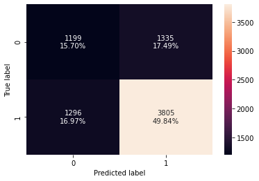

```python
confusion_matrix_sklearn(dTree, X_test, y_test) #building a confusion matrix based on dataset
```

**Observations**

- model is clearly overfitting between the train and test dataset
- confusion matrix is acceptable but could be better

### **Decision Tree Tuned**

```python
#Choose the type of classifier.
dtree_tuned = DecisionTreeClassifier(class_weight={0:0.67,1:0.33},random_state=1)

# Grid of parameters to choose from
parameters = {'max_depth': np.arange(2,10),
              'min_samples_leaf': [5, 7, 10, 15],
              'max_leaf_nodes' : [2, 3, 5, 10,15],
              'min_impurity_decrease': [0.0001,0.001,0.01,0.1]
             }

# Run the grid search
grid_obj = GridSearchCV(dtree_tuned, parameters, scoring='precision',n_jobs=-1)
grid_obj = grid_obj.fit(X_train, y_train)

# Set the clf to the best combination of parameters
dtree_tuned = grid_obj.best_estimator_

# Fit the best algorithm to the data.
dtree_tuned.fit(X_train, y_train)
```

```
DecisionTreeClassifier(class_weight={0: 0.67, 1: 0.33}, max_depth=4,
                       max_leaf_nodes=10, min_impurity_decrease=0.001,
                       min_samples_leaf=5, random_state=1)
```

```python
model_performance_classification_sklearn(dtree_tuned, X_train, y_train)
```

|  | Accuracy | Recall | Precision | F1 |
| --- | --- | --- | --- | --- |
| 0 | 0.710925 | 0.73084 | 0.817157 | 0.771592 |

```python
model_performance_classification_sklearn(dtree_tuned, X_test, y_test)
```

|  | Accuracy | Recall | Precision | F1 |
| --- | --- | --- | --- | --- |
| 0 | 0.705566 | 0.724172 | 0.814553 | 0.766708 |

```python
dtree_tuned_model_train_perf = model_performance_classification_sklearn(dtree_tuned, X_train, y_train)
```

```python
dtree_tuned_model_test_perf = model_performance_classification_sklearn(dtree_tuned, X_test, y_test)
```

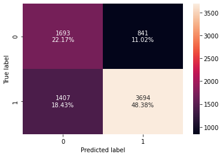

```python
confusion_matrix_sklearn(dtree_tuned, X_test, y_test)
```

**Observations**

- model looks good in terms of performance
- confusion matrix is poor, there are 18% false negatives and 11% false positives.
- we chose to focus on precision as we are focused on the certified population, the positive ones

### **Bagging Classifier**

```python
#bagging estimator with no specific parameters
bagging_estimator=BaggingClassifier(random_state=1)
bagging_estimator.fit(X_train, y_train)
model_performance_classification_sklearn(bagging_estimator, X_train, y_train)
```

|  | Accuracy | Recall | Precision | F1 |
| --- | --- | --- | --- | --- |
| 0 | 0.983101 | 0.984622 | 0.99003 | 0.987318 |

```python
model_performance_classification_sklearn(bagging_estimator, X_test, y_test)
```

|  | Accuracy | Recall | Precision | F1 |
| --- | --- | --- | --- | --- |
| 0 | 0.699411 | 0.778671 | 0.773063 | 0.775857 |

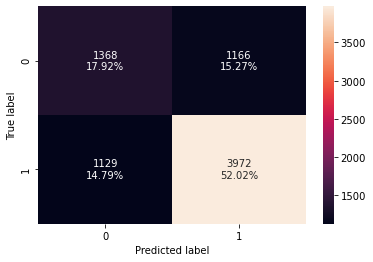

```python
confusion_matrix_sklearn(bagging_estimator, X_test, y_test)
```

**Observations**

- Model is overfitting
- confusion matrix is acceptable but could be better

```python
bagging_estimator_model_train_perf = model_performance_classification_sklearn(bagging_estimator, X_train, y_train)
```

```python
bagging_estimator_model_test_perf = model_performance_classification_sklearn(bagging_estimator, X_test, y_test)
```

### **Bagging Estimator Tuned**

```python
bagging_estimator_tuned = BaggingClassifier(base_estimator=DecisionTreeClassifier(criterion='gini', class_weight={1:0.33,0:0.67},random_state=1),random_state=1)

parameters = {'max_samples':[0.7,0.8,0.9,1],
              'max_features':[0.7,0.8,0.9,1],
              'n_estimators' : [50,100,150],
               }

grid_obj = GridSearchCV(bagging_estimator_tuned, parameters, scoring='precision', cv=5)
grid_obj = grid_obj.fit(X_train, y_train)

bagging_estimator_tuned = grid_obj.best_estimator_

bagging_estimator_tuned.fit(X_train, y_train)
```

```
BaggingClassifier(base_estimator=DecisionTreeClassifier(class_weight={0: 0.67,
                                                                      1: 0.33},
                                                        random_state=1),
                  max_features=0.9, max_samples=0.7, n_estimators=50,
                  random_state=1)
```

```python
model_performance_classification_sklearn(bagging_estimator_tuned, X_train, y_train)
```

|  | Accuracy | Recall | Precision | F1 |
| --- | --- | --- | --- | --- |
| 0 | 0.986414 | 0.995294 | 0.984539 | 0.989887 |

```python
model_performance_classification_sklearn(bagging_estimator_tuned, X_test, y_test)
```

|  | Accuracy | Recall | Precision | F1 |
| --- | --- | --- | --- | --- |
| 0 | 0.724558 | 0.850618 | 0.763908 | 0.804935 |

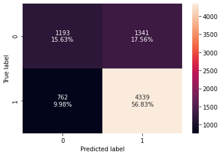

```python
confusion_matrix_sklearn(bagging_estimator_tuned, X_test, y_test)
```

**Observations**

- model is overfitting
- confusion mattrix is acceptable

```python
bagging_estimator_tuned_model_train_perf = model_performance_classification_sklearn(bagging_estimator_tuned, X_train, y_train)
```

```python
bagging_estimator_tuned_model_test_perf = model_performance_classification_sklearn(bagging_estimator_tuned, X_test, y_test)
```